# Reproducible Research Peer Assessment 1

Matt Gross

Sunday, April 19, 2015

```r
setwd("C:\\Users\\matt\\Dropbox\\Coursera\\Reproducible Research")
data <- read.csv("activity.csv", header = TRUE)
library(lubridate)
library(dplyr)
data$date <- ymd(data$date)
data <- mutate(data, timestamp = as.POSIXct(paste(data$date,sprintf(" %04d",data$interval),sep=""), format="%Y-%m-%d %H%M"))
data <- mutate(data, time_int = as.POSIXct(sprintf("%04d",data$interval), format="%H%M"))
```

1. What is mean total number of steps taken per day?

1a. Calculate the total number of steps taken per day:

```r
ttl_avg <- mean(data$steps,na.rm=TRUE)
data_by_date <- group_by(data, date)
ttl_steps_by_date <- summarise(data_by_date, total=sum(steps,na.rm=TRUE), avg_dt=mean(steps,na.rm=TRUE),avg_all=ttl_avg)
ttl_steps_by_date
```

```
## Source: local data frame [61 x 4]
##
##          date total   avg_dt avg_all
## 1  2012-10-01     0      NaN 37.3826
## 2  2012-10-02   126  0.43750 37.3826
## 3  2012-10-03 11352 39.41667 37.3826
## 4  2012-10-04 12116 42.06944 37.3826
## 5  2012-10-05 13294 46.15972 37.3826
## 6  2012-10-06 15420 53.54167 37.3826
## 7  2012-10-07 11015 38.24653 37.3826
## 8  2012-10-08     0      NaN 37.3826
## 9  2012-10-09 12811 44.48264 37.3826
## 10 2012-10-10  9900 34.37500 37.3826
## ..        ...   ...      ...     ...
```

1b. Make a histogram of the total number of steps taken each day.

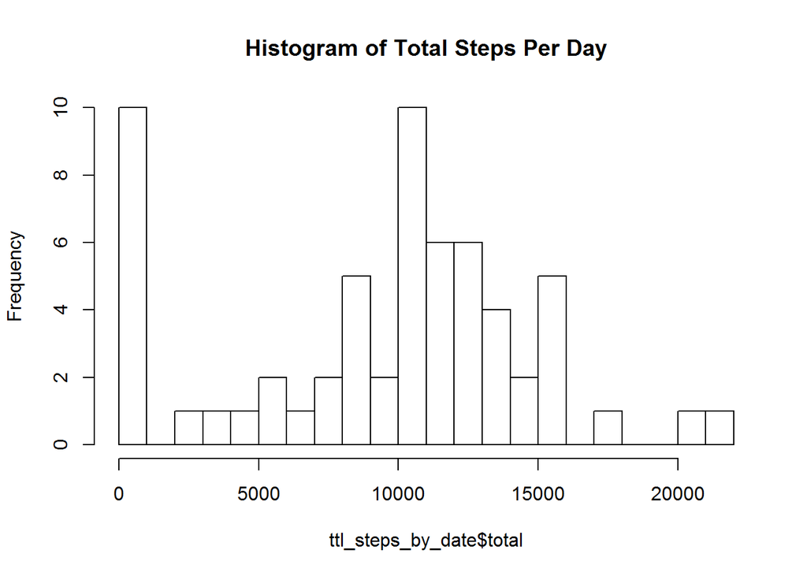

```r
library(ggplot2)
library(scales)
hist(ttl_steps_by_date$total, breaks = 20, main="Histogram of Total Steps Per Day")
```

1c. Calculate and report the mean and median of the total number of steps taken per day.

```r
t_mean <- mean(ttl_steps_by_date$total, na.rm = TRUE)
t_median <- median(ttl_steps_by_date$total, na.rm = TRUE)
print(paste("Mean of total steps: ",t_mean,sep=""))
```

```
## [1] "Mean of total steps: 9354.22950819672"
```

```r
print(paste("Median of total steps: ",t_median,sep=""))
```

```
## [1] "Median of total steps: 10395"
```

2. What is the average daily activity pattern?

2a. Make a time series plot (i.e. type = “l”) of the 5-minute interval (x-axis) and the average number of steps taken, averaged across all days (y-axis)

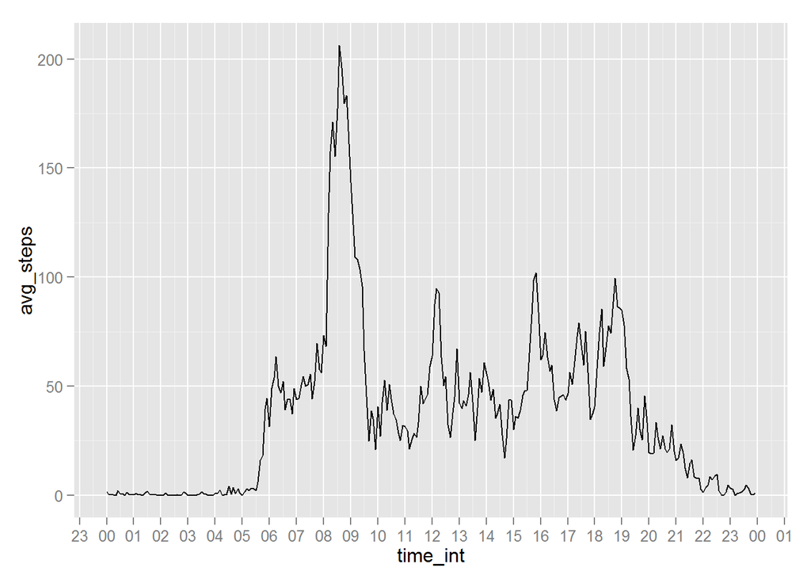

```r
data_by_time_int <- group_by(data, time_int)
data_by_time_int_avg_steps <- summarise(data_by_time_int, avg_steps=mean(steps,na.rm=TRUE))
#plot <- qplot(time_int, steps, data = data_by_time_int, geom = "line")
plot <- ggplot(data_by_time_int_avg_steps, aes(x=time_int, y = avg_steps)) + geom_line() + scale_x_datetime(breaks = date_breaks("1 hour"),labels=date_format("%H"))
print(plot)
```

2b. Which 5-minute interval, on average across all the days in the dataset, contains the maximum number of steps?

```r
max_index <- which.max(data_by_time_int_avg_steps$avg_steps)
print(paste("Max avg steps by 5-min interval: ", format(data_by_time_int_avg_steps[max_index,][1],"%H:%M"),sep=""))
```

```
## [1] "Max avg steps by 5-min interval: 08:35"
```

3. Inputing missing values